# Project: Investigating IMDB movie data

- Introduction
- Data Wrangling
- Exploratory Data Analysis
- Conclusions

## Introduction

I will be exploring, data wrangling, and making conclusions through this project. The used dataset contains information about 10,000 IMDB movies including vote averages (movie average ratings), budget, revenue, genres, keywords, and much more.

```python
import pandas as pd
import matplotlib.pyplot as plt
import numpy as np
%matplotlib inline
```

## Data Wrangling

### General Properties

```python
df = pd.read_csv('tmdb-movies.csv')
df.head(1)
```

|  | id | imdb_id | popularity | budget | revenue | original_title | cast | homepage | director | tagline | ... | overview | runtime | genres | production_companies | release_date | vote_count | vote_average | release_year | budget_adj | revenue_adj |
| --- | --- | --- | --- | --- | --- | --- | --- | --- | --- | --- | --- | --- | --- | --- | --- | --- | --- | --- | --- | --- | --- |
| 0 | 135397 | tt0369610 | 32.985763 | 150000000 | 1513528810 | Jurassic World | Chris Pratt\|Bryce Dallas Howard\|Irrfan Khan\|Vi... | http://www.jurassicworld.com/ | Colin Trevorrow | The park is open. | ... | Twenty-two years after the events of Jurassic ... | 124 | Action\|Adventure\|Science Fiction\|Thriller | Universal Studios\|Amblin Entertainment\|Legenda... | 6/9/15 | 5562 | 6.5 | 2015 | 1.379999e+08 | 1.392446e+09 |

1 rows × 21 columns

### Dataset description and info:

> I am just further exploring the dataset and visualizing tables that may help the data analysis process later on in the project.

We can notice there is missing values in our dataset. We should tackle this problem by dropping these rows with NA values. I checked for duplicated rows and rows having null values to drop them later I also explored the data types of various elements in the dataset. We can notice that all data types are consistent and non problematic.

```python
df.describe()
```

|  | id | popularity | budget | revenue | runtime | vote_count | vote_average | release_year | budget_adj | revenue_adj |
| --- | --- | --- | --- | --- | --- | --- | --- | --- | --- | --- |
| count | 10866.000000 | 10866.000000 | 1.086600e+04 | 1.086600e+04 | 10866.000000 | 10866.000000 | 10866.000000 | 10866.000000 | 1.086600e+04 | 1.086600e+04 |
| mean | 66064.177434 | 0.646441 | 1.462570e+07 | 3.982332e+07 | 102.070863 | 217.389748 | 5.974922 | 2001.322658 | 1.755104e+07 | 5.136436e+07 |
| std | 92130.136561 | 1.000185 | 3.091321e+07 | 1.170035e+08 | 31.381405 | 575.619058 | 0.935142 | 12.812941 | 3.430616e+07 | 1.446325e+08 |
| min | 5.000000 | 0.000065 | 0.000000e+00 | 0.000000e+00 | 0.000000 | 10.000000 | 1.500000 | 1960.000000 | 0.000000e+00 | 0.000000e+00 |
| 25% | 10596.250000 | 0.207583 | 0.000000e+00 | 0.000000e+00 | 90.000000 | 17.000000 | 5.400000 | 1995.000000 | 0.000000e+00 | 0.000000e+00 |
| 50% | 20669.000000 | 0.383856 | 0.000000e+00 | 0.000000e+00 | 99.000000 | 38.000000 | 6.000000 | 2006.000000 | 0.000000e+00 | 0.000000e+00 |
| 75% | 75610.000000 | 0.713817 | 1.500000e+07 | 2.400000e+07 | 111.000000 | 145.750000 | 6.600000 | 2011.000000 | 2.085325e+07 | 3.369710e+07 |
| max | 417859.000000 | 32.985763 | 4.250000e+08 | 2.781506e+09 | 900.000000 | 9767.000000 | 9.200000 | 2015.000000 | 4.250000e+08 | 2.827124e+09 |

We can see there are zero values in the min slots of budget_adj and revenue_adj which is unrealistic and should be tackled later on.

The maximum vote average is 9.2 and minimum is 1.5, which is in the range from 1 to 10.

```python
df.info()
```

```
<class 'pandas.core.frame.DataFrame'>
RangeIndex: 10866 entries, 0 to 10865
Data columns (total 21 columns):
id                      10866 non-null int64
imdb_id                 10856 non-null object
popularity              10866 non-null float64
budget                  10866 non-null int64
revenue                 10866 non-null int64
original_title          10866 non-null object
cast                    10790 non-null object
homepage                2936 non-null object
director                10822 non-null object
tagline                 8042 non-null object
keywords                9373 non-null object
overview                10862 non-null object
runtime                 10866 non-null int64
genres                  10843 non-null object
production_companies    9836 non-null object
release_date            10866 non-null object
vote_count              10866 non-null int64
vote_average            10866 non-null float64
release_year            10866 non-null int64
budget_adj              10866 non-null float64
revenue_adj             10866 non-null float64
dtypes: float64(4), int64(6), object(11)
memory usage: 1.7+ MB
```

I am fine with most of these data types, so I would not be doing any data type transformations.

```python
df.duplicated().sum()
```

```
1
```

```python
df.isnull().any().sum()
```

```
9
```

### budget_adj and revenue_adj with zero values:

Here, I am checking if some rows has faulty information through checking if the budget or revenue values may be zero. I would assume zero budget or revenue values as NA values and ignore them.

```python
df_zero = df.query('budget_adj==0 or revenue_adj==0')
df_zero.head(1)
```

|  | id | imdb_id | popularity | budget | revenue | original_title | cast | homepage | director | tagline | ... | overview | runtime | genres | production_companies | release_date | vote_count | vote_average | release_year | budget_adj | revenue_adj |
| --- | --- | --- | --- | --- | --- | --- | --- | --- | --- | --- | --- | --- | --- | --- | --- | --- | --- | --- | --- | --- | --- |
| 30 | 280996 | tt3168230 | 3.927333 | 0 | 29355203 | Mr. Holmes | Ian McKellen\|Milo Parker\|Laura Linney\|Hattie M... | http://www.mrholmesfilm.com/ | Bill Condon | The man behind the myth | ... | The story is set in 1947, following a long-ret... | 103 | Mystery\|Drama | BBC Films\|See-Saw Films\|FilmNation Entertainme... | 6/19/15 | 425 | 6.4 | 2015 | 0.0 | 2.700677e+07 |

1 rows × 21 columns

There are zero value budgets or revenues. I ought to tackle this later on by excluding the rows containing these null values.

### Movie genres and production companies:

```python
df.genres.value_counts()
```

```
Comedy                                                712
Drama                                                 712
Documentary                                           312
Drama|Romance                                         289
Comedy|Drama                                          280
Comedy|Romance                                        268
Horror|Thriller                                       259
Horror                                                253
Comedy|Drama|Romance                                  222
Drama|Thriller                                        138
Comedy|Family                                         102
Action|Thriller                                       101
Thriller                                               93
Drama|Comedy                                           92
Animation|Family                                       90
Crime|Drama|Thriller                                   81
Crime|Drama                                            74
Comedy|Horror                                          72
Drama|Comedy|Romance                                   64
Action                                                 63
Action|Comedy                                          62
Drama|History                                          58
Action|Crime|Drama|Thriller                            54
Drama|Horror|Thriller                                  53
Action|Crime|Thriller                                  52
Horror|Science Fiction                                 52
Horror|Mystery|Thriller                                51
Comedy|Crime                                           50
Documentary|Music                                      49
Drama|Music                                            49
                                                     ...
Comedy|Romance|Adventure                                1
Comedy|Family|Fantasy|Romance                           1
TV Movie|Animation|Family                               1
Drama|Comedy|History|Music                              1
Drama|Mystery|Thriller|Crime|Romance                    1
Drama|Thriller|Mystery|Music|Romance                    1
Fantasy|Science Fiction|Animation|Action|Adventure      1
Horror|Science Fiction|TV Movie                         1
Mystery|Drama|Science Fiction|Thriller                  1
Action|Science Fiction|Adventure|Comedy|Family          1
Music|Comedy|Crime                                      1
Action|Thriller|Comedy|Crime                            1
Science Fiction|Mystery|Horror|Thriller                 1
TV Movie|Animation|Fantasy                              1
Thriller|Action|Drama|Music|Romance                     1
Drama|Horror|Mystery|Science Fiction|Thriller           1
Animation|Romance|Family|Fantasy                        1
Drama|Family|Comedy|TV Movie                            1
TV Movie|Comedy|Drama|Romance                           1
Thriller|Action|Comedy|Science Fiction                  1
History|Drama|Thriller|Crime|Mystery                    1
Adventure|Drama|Action|Family|Foreign                   1
Thriller|Action|Science Fiction|Horror|Mystery          1
Drama|Foreign|Mystery                                   1
Adventure|Drama|Action|Thriller|Crime                   1
Romance|Science Fiction                                 1
Action|Science Fiction|Adventure|Mystery                1
Action|Drama|Foreign|Mystery|Thriller                   1
Thriller|Adventure|Fantasy                              1
Comedy|Science Fiction|Thriller|Adventure               1
Name: genres, Length: 2039, dtype: int64
```

We can there are a lot of multiple-value genres. I shall split them later on.

```python
df.production_companies.value_counts()
```

```
Paramount Pictures                                                                                             156
Universal Pictures                                                                                             133
Warner Bros.                                                                                                    84
Walt Disney Pictures                                                                                            76
Metro-Goldwyn-Mayer (MGM)                                                                                       72
Columbia Pictures                                                                                               72
New Line Cinema                                                                                                 61
Touchstone Pictures                                                                                             51
20th Century Fox                                                                                                50
Twentieth Century Fox Film Corporation                                                                          49
TriStar Pictures                                                                                                45
Orion Pictures                                                                                                  42
Miramax Films                                                                                                   32
Columbia Pictures Corporation                                                                                   31
DreamWorks Animation                                                                                            31
Pixar Animation Studios                                                                                         30
Walt Disney Productions                                                                                         29
Dimension Films                                                                                                 28
United Artists                                                                                                  23
Imagine Entertainment|Universal Pictures                                                                        22
Marvel Studios                                                                                                  22
The Asylum                                                                                                      21
Lions Gate Films                                                                                                21
New World Pictures                                                                                              17
Walt Disney Pictures|Pixar Animation Studios                                                                    17
Disney Channel                                                                                                  14
American International Pictures (AIP)                                                                           14
Hammer Film Productions                                                                                         13
Hollywood Pictures                                                                                              12
Walt Disney Pictures|Walt Disney Feature Animation                                                              12
                                                                                                              ...
TriStar Pictures|NFH Productions                                                                                 1
Metro-Goldwyn-Mayer (MGM)|David Ladd Films                                                                       1
Hemdale Film Corporation|Magellan Pictures                                                                       1
Village Roadshow Pictures|NPV Entertainment|Warner Bros.|The Canton Company|Mars Production Pty. Ltd.            1
Columbia Pictures|Blinding Edge Pictures|Overbrook Entertainment                                                 1
Industry Entertainment|Imagenation Abu Dhabi FZ|Hyde Park Entertainment|Agent Two|Brandt/Haas Productions        1
Columbia Pictures|Imagine Entertainment|Revolution Studios                                                       1
Paramount Pictures|Mace Neufeld Productions|Rysher Entertainment                                                 1
Media Rights Capital|Lin Pictures|Warner Bros.|Darko Entertainment|Radar Pictures                                1
RabbitBandini Productions                                                                                        1
```

[output cut: 21 more lines]

### Questions to address:

First, what genre has the highest ratings of all?

Second, What genre needs a bigger budget and which produces a higher profit?

Third, Are recent horror movies rating more?

### Preparing my data frame for the first question:

First of all, I start with dropping the duplicates.

Then, I have to separate the genres from multiple values separated by pipe (|) characters to single values, each have its count and average movie ratings. To do so, I create a series that holds value counts of all movie genres. I, then, create a data frame that holds every movie genre against the mean of its associated movies average ratings. Then, I split the multiple value genres into single genres while maintaining the mean of movie average ratings.

```python
df.drop_duplicates(inplace=True)
```

```python
df_genres=pd.concat([df,df['genres'].str.get_dummies(sep="|")], axis =1)
df_genres.Drama.sum()
```

```
4760
```

Now, we can get the sum of movies of each genre separately

```python
df_genres.info()
```

```
<class 'pandas.core.frame.DataFrame'>
Int64Index: 10865 entries, 0 to 10865
Data columns (total 41 columns):
id                      10865 non-null int64
imdb_id                 10855 non-null object
popularity              10865 non-null float64
budget                  10865 non-null int64
revenue                 10865 non-null int64
original_title          10865 non-null object
cast                    10789 non-null object
homepage                2936 non-null object
director                10821 non-null object
tagline                 8041 non-null object
keywords                9372 non-null object
overview                10861 non-null object
runtime                 10865 non-null int64
genres                  10842 non-null object
production_companies    9835 non-null object
release_date            10865 non-null object
vote_count              10865 non-null int64
vote_average            10865 non-null float64
release_year            10865 non-null int64
budget_adj              10865 non-null float64
revenue_adj             10865 non-null float64
Action                  10865 non-null int64
Adventure               10865 non-null int64
Animation               10865 non-null int64
Comedy                  10865 non-null int64
Crime                   10865 non-null int64
Documentary             10865 non-null int64
Drama                   10865 non-null int64
Family                  10865 non-null int64
Fantasy                 10865 non-null int64
Foreign                 10865 non-null int64
History                 10865 non-null int64
Horror                  10865 non-null int64
Music                   10865 non-null int64
Mystery                 10865 non-null int64
Romance                 10865 non-null int64
Science Fiction         10865 non-null int64
TV Movie                10865 non-null int64
Thriller                10865 non-null int64
War                     10865 non-null int64
Western                 10865 non-null int64
dtypes: float64(4), int64(26), object(11)
memory usage: 3.5+ MB
```

Action, Adventure, Animation, Comedy, Crime, Documentary, Drama, Family, Fantasy, Foreign, History, Horror, Music, Mystery, Romance, Science Fiction, TV Movie, Thriller, War, and Western are the present genres. Totally, 20 genres.

```python
df_genres.query('Drama==1').vote_average.mean()
```

```
6.1655462184873953
```

Here, I outputed the mean of average ratings for movies in the Drama genre.

```python
df_genres.rename(columns = lambda x : x.replace(" ", "_"), inplace=True)
```

```python
df_genres.info()
```

```
<class 'pandas.core.frame.DataFrame'>
Int64Index: 10865 entries, 0 to 10865
Data columns (total 41 columns):
id                      10865 non-null int64
imdb_id                 10855 non-null object
popularity              10865 non-null float64
budget                  10865 non-null int64
revenue                 10865 non-null int64
original_title          10865 non-null object
cast                    10789 non-null object
homepage                2936 non-null object
director                10821 non-null object
tagline                 8041 non-null object
keywords                9372 non-null object
overview                10861 non-null object
runtime                 10865 non-null int64
genres                  10842 non-null object
production_companies    9835 non-null object
release_date            10865 non-null object
vote_count              10865 non-null int64
vote_average            10865 non-null float64
release_year            10865 non-null int64
budget_adj              10865 non-null float64
revenue_adj             10865 non-null float64
Action                  10865 non-null int64
Adventure               10865 non-null int64
Animation               10865 non-null int64
Comedy                  10865 non-null int64
Crime                   10865 non-null int64
Documentary             10865 non-null int64
Drama                   10865 non-null int64
Family                  10865 non-null int64
Fantasy                 10865 non-null int64
Foreign                 10865 non-null int64
History                 10865 non-null int64
Horror                  10865 non-null int64
Music                   10865 non-null int64
Mystery                 10865 non-null int64
Romance                 10865 non-null int64
Science_Fiction         10865 non-null int64
TV_Movie                10865 non-null int64
Thriller                10865 non-null int64
War                     10865 non-null int64
Western                 10865 non-null int64
dtypes: float64(4), int64(26), object(11)
memory usage: 3.5+ MB
```

We can see how the names of genre columns changed and spaces were replaced by underscores

```python
labels = ['vote_average']
votings = list()
for col in df_genres.columns[22:]:
    q = col +'==1'
    votings.append(df_genres.query(q).vote_average.mean())
data = {'vote_average': votings}
df_votes = pd.DataFrame(data, columns=labels,index=df_genres.columns[22:])
df_votes
```

[output not shown]

Now, we have a dataframe of genres with the corresponding mean of ratings of associated movies

### Preparing my data frame for the second question:

Since I deduced in the wrangling section that some movies have their budget_adj or revenue_adj set to zero, I create a new data frame that is a copy of the "df" dataframe but with the zero value budget_adj or revenue_adj rows dropped for convenience. I treat the zero value for budget and revenue as NA because it is unreal to have such budget or revenue for a movie.

Then, I create a new series that contains value counts of genres present in the new data frame: "df_second". I create two new dataframes: one to carry mean budget_adj and the other to carry mean profit. And like I did with the first question preparation, I go on splitting multiple value genres. But, this time, every genre is given a mean for budget_adj and profit instead of ratings.

```python
df.isnull().sum()
```

```
id                         0
imdb_id                   10
popularity                 0
budget                     0
revenue                    0
original_title             0
cast                      76
homepage                7929
director                  44
tagline                 2824
keywords                1493
overview                   4
runtime                    0
genres                    23
production_companies    1030
release_date               0
vote_count                 0
vote_average               0
release_year               0
budget_adj                 0
revenue_adj                0
dtype: int64
```

There are no null values in budget and revenue; however, I shall check for zero values and eleminate them.

```python
df_second = df.copy()
df_second.drop(index=df_second.query('budget_adj==0 or revenue_adj == 0').index, inplace=True)
```

```python
df_second.query('budget_adj==0 or revenue_adj == 0')
```

|  | id | imdb_id | popularity | budget | revenue | original_title | cast | homepage | director | tagline | ... | overview | runtime | genres | production_companies | release_date | vote_count | vote_average | release_year | budget_adj | revenue_adj |
| --- | --- | --- | --- | --- | --- | --- | --- | --- | --- | --- | --- | --- | --- | --- | --- | --- | --- | --- | --- | --- | --- |

0 rows × 21 columns

I, now, need to add a column for net profit

```python
df_second['profit'] = df_second.revenue_adj - df_second.budget_adj
df_second.head(1)
```

|  | id | imdb_id | popularity | budget | revenue | original_title | cast | homepage | director | tagline | ... | runtime | genres | production_companies | release_date | vote_count | vote_average | release_year | budget_adj | revenue_adj | profit |
| --- | --- | --- | --- | --- | --- | --- | --- | --- | --- | --- | --- | --- | --- | --- | --- | --- | --- | --- | --- | --- | --- |
| 0 | 135397 | tt0369610 | 32.985763 | 150000000 | 1513528810 | Jurassic World | Chris Pratt\|Bryce Dallas Howard\|Irrfan Khan\|Vi... | http://www.jurassicworld.com/ | Colin Trevorrow | The park is open. | ... | 124 | Action\|Adventure\|Science Fiction\|Thriller | Universal Studios\|Amblin Entertainment\|Legenda... | 6/9/15 | 5562 | 6.5 | 2015 | 1.379999e+08 | 1.392446e+09 | 1.254446e+09 |

1 rows × 22 columns

```python
df_budget =pd.concat([df_second,df_second['genres'].str.get_dummies(sep="|")], axis =1)
df_budget.query('Drama==1 ').budget_adj.mean()
```

```
34712463.724212602
```

```python
df_budget.query('Animation==1').profit.mean()
```

```
207485229.34557885
```

```python
df_budget.rename(columns = lambda x : x.replace(" ", "_"), inplace=True)
```

```python
df_budget.info()
```

```
<class 'pandas.core.frame.DataFrame'>
Int64Index: 3854 entries, 0 to 10848
Data columns (total 42 columns):
id                      3854 non-null int64
imdb_id                 3854 non-null object
popularity              3854 non-null float64
budget                  3854 non-null int64
revenue                 3854 non-null int64
original_title          3854 non-null object
cast                    3850 non-null object
homepage                1426 non-null object
director                3853 non-null object
tagline                 3574 non-null object
keywords                3716 non-null object
overview                3854 non-null object
runtime                 3854 non-null int64
genres                  3854 non-null object
production_companies    3808 non-null object
release_date            3854 non-null object
vote_count              3854 non-null int64
vote_average            3854 non-null float64
release_year            3854 non-null int64
budget_adj              3854 non-null float64
revenue_adj             3854 non-null float64
profit                  3854 non-null float64
Action                  3854 non-null int64
Adventure               3854 non-null int64
Animation               3854 non-null int64
Comedy                  3854 non-null int64
Crime                   3854 non-null int64
Documentary             3854 non-null int64
Drama                   3854 non-null int64
Family                  3854 non-null int64
Fantasy                 3854 non-null int64
Foreign                 3854 non-null int64
History                 3854 non-null int64
Horror                  3854 non-null int64
Music                   3854 non-null int64
Mystery                 3854 non-null int64
Romance                 3854 non-null int64
Science_Fiction         3854 non-null int64
TV_Movie                3854 non-null int64
Thriller                3854 non-null int64
War                     3854 non-null int64
Western                 3854 non-null int64
dtypes: float64(5), int64(26), object(11)
memory usage: 1.3+ MB
```

We can see how the names of genre columns changed and spaces were replaced by underscores

```python
labels = ['profit', 'budget']
profits = list()
budgets = list()
for col in df_budget.columns[22:]:
    q = col +'==1'
    profits.append(df_budget.query(q).profit.mean())
    budgets.append(df_budget.query(q).budget_adj.mean())
data = {'profit': profits, 'budget': budgets }
df_combined = pd.DataFrame(data, columns=labels,index=df_budget.columns[22:])
df_combined
```

| <function <lambda> at 0x7fe2283c87b8> | profit | budget |
| --- | --- | --- |
| Action | 1.289453e+08 | 6.644262e+07 |
| Adventure | 1.901517e+08 | 8.125573e+07 |
| Animation | 2.074852e+08 | 8.347215e+07 |
| Comedy | 8.213206e+07 | 3.917646e+07 |
| Crime | 7.048507e+07 | 3.991007e+07 |
| Documentary | 1.942646e+07 | 5.379702e+06 |
| Drama | 6.666600e+07 | 3.471246e+07 |
| Family | 1.726900e+08 | 7.110099e+07 |
| Fantasy | 1.697552e+08 | 8.023752e+07 |
| Foreign | -1.644639e+05 | 1.289824e+07 |
| History | 6.478188e+07 | 5.687985e+07 |
| Horror | 5.816584e+07 | 2.324071e+07 |
| Music | 9.936800e+07 | 3.519802e+07 |
| Mystery | 7.125838e+07 | 4.236264e+07 |
| Romance | 7.961554e+07 | 3.390431e+07 |
| Science_Fiction | 1.365359e+08 | 6.561722e+07 |
| TV_Movie | 5.143802e+07 | 6.951084e+06 |
| Thriller | 8.356913e+07 | 4.460177e+07 |
| War | 9.862516e+07 | 5.727295e+07 |
| Western | 6.848370e+07 | 6.719107e+07 |

This is a data frame hodling the name of each genre facing its associated average for expected budget and profit.

Here, we can also see that Animation has the highest profit and budget of all. Foreign has a negative profit beacause the revenues of some movies of the same genre are lower than budgets.

```python
df_budget.query('Animation==1').profit.mean()
```

```
207485229.34557885
```

Here, I was checking to compare if my data in the new data frame, df_combined, is correct.

### Preparing my data frame for the third question:

I decided to assume that horror movies after 2000 are "recent" while horror movies before that are "old". Here, I create two dataframes: one for the recent movies and the other for the old ones. I then create a series for both dataframes to carry value counts of genres.

Then, like the first question preparation, I go on splitting multiple value genres and maintaining a mean of movie average ratings for the corresponding genres.

```python
df_recent = df.query('release_year>=2000')
df_old = df.query('release_year<2000')
df_recent.head(1)
df_old.head(1)
```

|  | id | imdb_id | popularity | budget | revenue | original_title | cast | homepage | director | tagline | ... | overview | runtime | genres | production_companies | release_date | vote_count | vote_average | release_year | budget_adj | revenue_adj |
| --- | --- | --- | --- | --- | --- | --- | --- | --- | --- | --- | --- | --- | --- | --- | --- | --- | --- | --- | --- | --- | --- |
| 1329 | 11 | tt0076759 | 12.037933 | 11000000 | 775398007 | Star Wars | Mark Hamill\|Harrison Ford\|Carrie Fisher\|Peter ... | http://www.starwars.com/films/star-wars-episod... | George Lucas | A long time ago in a galaxy far, far away... | ... | Princess Leia is captured and held hostage by ... | 121 | Adventure\|Action\|Science Fiction | Lucasfilm\|Twentieth Century Fox Film Corporation | 3/20/77 | 4428 | 7.9 | 1977 | 3.957559e+07 | 2.789712e+09 |

1 rows × 21 columns

```python
df_horror =pd.concat([df_recent,df_recent['genres'].str.get_dummies(sep="|")], axis =1)
df_ohorror =pd.concat([df_old,df_old['genres'].str.get_dummies(sep="|")], axis =1)
(df_horror.query('Horror==1 ').vote_average.mean(),df_ohorror.query('Horror==1 ').vote_average.mean())
```

```
(5.1217472118959106, 5.7511586452762922)
```

We can notice that horror movies did not improve over time in terms of movie ratings but instead declined

```python
horror = df_horror.query('Horror==1 ').vote_average.mean()
ohorror = df_ohorror.query('Horror==1 ').vote_average.mean()
```

## Exploratory Data Analysis

### What genre has the highest ratings of all?

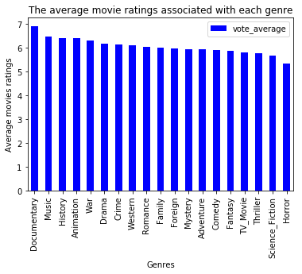

```python
df_votes.sort_values(inplace=True,ascending=False,by='vote_average')
ab = df_votes.plot( y='vote_average', kind='bar', title='The average movie ratings associated with each genre',colors='b');
ab.set_ylabel("Average movies ratings");
ab.set_xlabel("Genres");
```

It appears that documentaries are a safe bet when it comes to movie ratings while horror movies have the least mean of movies average ratings.

### What genre needs a bigger budget and which generates a higher profit?

```python
budget = df_combined.budget.copy()
profit = df_combined.profit.copy()
```

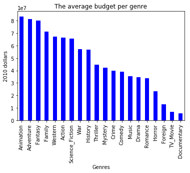

```python
budget.sort_values(inplace=True,ascending=False)
ba = budget.plot(x='genres', y='budget_average', kind='bar', title='The average budget per genre',colors='b');
ba.set_ylabel("2010 dollars");
ba.set_xlabel("Genres");
```

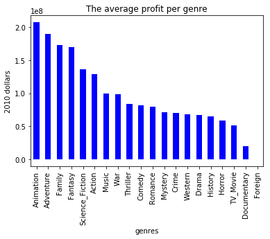

```python
profit.sort_values(inplace=True,ascending=False)
bb =profit.plot(x='genres', y='profit average', kind='bar', title='The average profit per genre',colors='b');
bb.set_ylabel("2010 dollars");
bb.set_xlabel("genres");
```

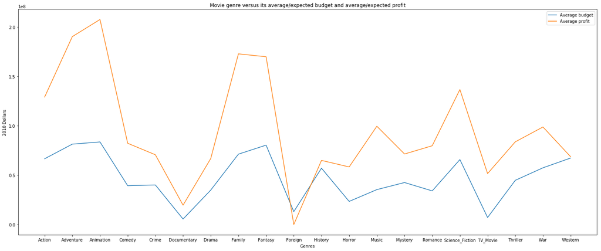

```python
plt.figure(figsize=(25,10))
plt.plot(df_combined.index, df_combined.budget, label = "Average budget" )
plt.plot(df_combined.index,  df_combined.profit, label = "Average profit" )
plt.xlabel("Genres")
plt.ylabel("2010 Dollars")
plt.title("Movie genre versus its average/expected budget and average/expected profit")
plt.legend()
```

It appears that animation is the most demanding genre in budget while also being the most rewarding in profit. I also appears that while documentaries are low-budget, they are also low-profit

### Are recent horror movies rating more?

```
Text(0,0.5,'Average ratings')
```

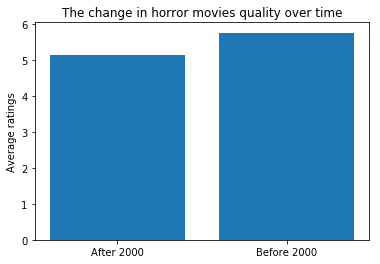

```python
plt.bar(["After 2000","Before 2000"],[horror,ohorror])
plt.title("The change in horror movies quality over time")
plt.ylabel("Average ratings")
```

It appears that horror movies did not experience a noticable improvement over the years, but there was even a decline.

## Conclusions

**Limitations:**

1. There were a lot of data rows with missing budget and revenue values causing statistics to be less accurate depending on less data.

## Submitting your Project

```python
from subprocess import call
call(['python', '-m', 'nbconvert', 'Investigate_a_Dataset.ipynb'])
```

```
0
```